# Backtesting Project: finding significant factors

Bowen Liu

May 4, 2018

## Introduction

I will be using what I learned in my CMSC320 class about tidying the data and commute my result via RMD. Speical thank you to Professor Héctor Corrada Bravo for helping me with this project.

This tutorial will show you how I extracted the data from WRDS(https://wrds-web.wharton.upenn.edu/wrds/) and finical factors to analyze how well the elements perform in the period 1985-2013. The goal is to see can we train this model to make it do well in the future?

I will be training the model on the backtesting period and then test the model against the training period, and we will see how well we can do with this model. The whole idea is when we are training the model we use all the factors, and after the training, we do a correlation analysis and t-stat analysis to see whether or not a factor is significant, and we only keep those that are significant.

I will be using machine learning concepts in the backtesting process. A quick overview is that I will be splitting the data 50/50 and train the model using the training period and then test it on the testing data to get the result and see how we do. Let’s start.

### Libraries

The following libraries are used in this project. In order to do certain task you will need to have these libraries installed.

- library(dplyr)
- library(tidyverse)
- library(xtable)
- library(broom)
- library(tidyr)
- library(ggplot2)
- library(scales)
- library(magrittr)
- library(readxl)
- library(knitr)
- library(stringr)
- library(randomForest)
- library(DT)
- library(kableExtra)
- library(data.table)
- library(Hmisc)
- library(corrplot)
- library(lmtest)
- library(sandwich)

## Factors I used for this project

### 12 JKKL Factors

These 12 are ranked the best factors and is hard to do better than these 12 factors. Here I have a quick explaination for each of the 12 factors.

Reading that can help you understand this concept: https://papers.ssrn.com/sol3/papers.cfm?abstract_id=291241

| Number | Factors | Category | Descriptions | Effect_on_stock |
| --- | --- | --- | --- | --- |
| 1 | RETP | Momentum | Cumulative Market Adjusted Return for the Preceding 6 Months | pos |
| 2 | RETP2 | Momentum | Cumulative Market Adjusted Return for the 2nd Preceding 6 Months | pos |
| 3 | TURN | Trading Volume | Average Daily Volume Turnover | neg |
| 4 | SIZE | Size | Market Cap (Natural Log) | neg |
| 5 | FREV | Earning Surpirse | Analyst earnings forecast revisions to price | pos |
| 6 | LTG | Growth | Long-term growth forecast | neg |
| 7 | SUE | Earning Surprise | Standardized unexpected earnings | pos |
| 8 | SG | Growth | Sales Growth | neg |
| 9 | TA | Earning Quality | Total Accruals to total assets | neg |
| 10 | CAPEX | Growth | Capital expenditures to total assets | neg |
| 11 | BP | Growth | Book to Price | pos |
| 12 | EP | Growth | Earnings to Price | pos |

On top of the 12 factors I picked a few more to compare them against the JKKL 12 factors. Some of the new factors here can potentially do better in combination of the JKKL such as total Q which is a factor that was recently developed.

| Number | Factors | Descriptions | Research |
| --- | --- | --- | --- |
| 13 | DP | Historically, there has a been a positive relation between Dividend/Price or Dividend Yield and future returns | Litzenberger and Ramaswamy (1982) |
| 14 | Volume | Firms with larger amounts of volume subsequently have lower furture returns | Ang et al. (2006) |
| 15 | total Q | Total Q is a new proxy for Tobin’s Q. Tobin’s Q is traditionally Market Equity value + Market value of liabilities divided by equity book value + liabilities book value. Total Q includes intangible ca… | Peters and Taylor (2016) |
| 16 | Off Balance Sheet Asset(OffBS) | what degree intangible capital is kept off of or not listed on the balance sheet | Peters and Taylor (2016) |
| 17 | M-Score | Attempts to encapsulate likelihood of firm-level earnings manipulation. This factor uses eight sub-factors calculated with compustat data; additionally, Beneish finds that firms with a score greater t… | Beneish’s paper |

## Model

I have downloaded all the csv files from WRDS and I am using it purely for this model and we can get the speicfic factors from WRDS which is really nice.

```r
setwd("C:/Users/Bowin/Desktop/Spring2018/442/FinalPort")

## Data Imports
JKKL = fread('jkkl.csv')
```

[output not shown]

```r
mk = fread('mk.csv')
```

[output not shown]

```r
#crsp = as.data.table(read_csv("CRSP.csv"))

crsp = fread("CRSP2.csv")
```

```
##
Read 39.4% of 2970902 rows
Read 66.0% of 2970902 rows
Read 92.6% of 2970902 rows
Read 2970902 rows and 8 (of 8) columns from 0.144 GB file in 00:00:05
```

```r
link = fread("LinkingTable.csv")
totalq = fread("totalq.csv")
ff38 = setDT(read_excel("lab6_ffdata.xlsx", sheet = "sic38", range = "A1:D41", col_names = F))
FFMonthly = setDT(read_excel("ff_data.xlsx", sheet = "2001_2013", range = "A1:F160"))
```

Data Collection First I tidy the data to making it easy to use and understand for my purposes. Here I have adjusted the column names for some of the csv files I got. I have also omit column that is empty in the data. Here I choose to remove the data becasue after carefully studied the data we haev enough samples and is hard to find a placeholder thus removing it will be the best chose.

```r
# setting column names
setnames(crsp, c("permno", "date", "siccd", "ticker", "divamt", "prc", "ret", "shrout"))
setnames(ff38, c("start", "end", "ind", "indname"))

# matching siccd to fama & french industry classification, merged so we have ind column, will be used for winsorize later
crsp2 = crsp[!is.na(siccd) && siccd != 0]
crsp2 = crsp2[, siccd := as.double(siccd)]
crsp2 = crsp2[!is.na(siccd)]
crsp2 = crsp2[ff38, on = list(siccd >= start, siccd <= end), nomatch = 0][, siccd.1 := NULL]

# merging with link table on gvkey to get permno column, 297k obs before merge and 228k after merge, mostly matches, works no problem
totalq2 = na.omit(totalq[link, on = "gvkey"])
totalq2 = totalq2[, .SD, .SDcols = c("LPERMNO", "fyear", "q_tot", "K_int_offBS" )]
setnames(totalq2, c("permno", "year", "q_tot", "K_int_offBS"))
```

Here I tidy the datatables and joined them with the overall Data table where I have all the information in one file for easy access and caculated some of the factors that was not provided. I also had to change the date format so I can either just extract the year of the month. This way When I caculate the lag of a factors I can simpliy find the +1 year. I then used the winsorized regressors to create the new column based on the numeric values and stored by year.

```r
# Get yearly returns from compunded monthly returns of all crsp stocks
crsp2[, year := as.numeric(format(as.Date(date, format="%m/%d/%Y"), "%Y"))]
crsp2[, month := format(as.Date(date, format="%m/%d/%Y"), "%m")]
crsp2[, yearlyRet := prod(as.numeric(ret)+1)-1, by = .(permno, year)]
crsp2 = na.omit(crsp2[month == 12][,c("date","month","ret"):=NULL])

# choose the jkkl factors and some more
JKKL2 = JKKL[, .SD, .SDcols = c("permno", "date", "compustat_date", "retp", "ret2p", "turn", "lagsize", "FREV",
                               "LTG", "SUE", "SG", "ta", "CAPEX", "bp", "EP", "VOL")]

# use 4th quarter for yearly factor data
JKKL2[, year := as.numeric(format(as.Date(compustat_date, format="%m/%d/%Y"), "%Y"))+1]
JKKL2[, month := format(as.Date(date, format="%m/%d/%Y"), "%m")]
JKKL2 = JKKL2[month == 12][,c("date","month"):=NULL]

# merge the tables together by permno and year to have all the columns with factors we want
Data = na.omit(as.data.table(left_join(JKKL2, crsp2, by= c("permno","year")))[,c("compustat_date"):=NULL])
Data = na.omit(as.data.table(left_join(Data, totalq2, by= c("permno","year"))))
# mk table is too small after merge with link
#Data = na.omit(as.data.table(left_join(Data, mk2, by= c("permno","year"))))
Data[, DP := divamt/prc][,c("divamt","prc"):=NULL]

# the factors we will use, the x variables we will use to predict y (monthly returns)
X_factors = colnames(Data)[c(2:14,22:24)]

# winsorize regressors
Wins = function(x, left, right) {
  q = quantile(x, c(left,right), type = 5)
  indx = findInterval(x, q,left.open = TRUE)
  x[indx == 0] <- q[[1]]
  x[indx == 2] <- q[[2]]
  x
}


# clean data with winsorizing, not removing but changing outliers to farthest non outlier value
Data = Data[, c(.(permno = permno, ind=ind, yearlyRet=yearlyRet), lapply(.SD, function(x) Wins(as.numeric(x), 0.025,0.975))), by = "year", .SDcols = X_factors]
```

### Training

Here’s what the Datatable looks like after we did everything:

```r
head(Data,5)
```

```
##    year permno ind  yearlyRet        retp       ret2p      turn  lagsize
## 1: 1993  10010  24 -0.4153792  0.04635837 -0.33497324 23.488430 11.25170
## 2: 1993  10074  20  0.5494987 -0.13162166  0.40484643 57.700921 10.55641
## 3: 1993  10138  35  0.2592031  0.15833998 -0.01834576 53.869122 13.33725
## 4: 1993  10138  35  0.2592031  0.15833998 -0.01834576 53.869122 13.33725
## 5: 1993  10147  22  1.7789487  0.63323234  0.57894882  5.163551 13.57594
##           FREV     LTG        SUE       SG          ta      CAPEX
## 1: -0.04944709 28.9375 -1.6160340 1.352598  0.03519428 0.06290010
## 2:  0.00000000 28.9375 -0.3994654 1.419220 -0.04426388 0.12948991
## 3:  0.00000000 13.2500  0.5658795 1.244849 -0.06458850 0.04420138
## 4:  0.00000000 13.2500  0.5658795 1.244849 -0.06458850 0.04420138
## 5:  0.00000000 28.9375  1.1973422 1.515659  0.12660722 0.10516545
##           bp          EP   VOL      q_tot K_int_offBS          DP
## 1: 0.2784134 -0.03462688 12407  0.9440737   33.051460 0.000000000
## 2: 0.2093319  0.06666672   853  1.2400050    5.678446 0.004545455
## 3: 0.2780287  0.06231292 11920 10.6024800    0.000000 0.004482759
## 4: 0.2780287  0.06231292 11920 10.6024800    0.000000 0.000000000
## 5: 0.2712372  0.04047619 44671  7.8852210  199.970300 0.000000000
```

Here is when the backtesting take place I first divide the sample data into training and testing data.

*** Training Period *** 1985-1998

I then omited the table one last time to make sure the data tables can be used in the training and produce accurate result without having to worried about N/A datas. Here we have Data_IN as the training period and Data_out as the testing period.

```r
# stadardize all of the factors by getting the z-scores, maintaing same distibution of the per factor per year data, but it doesn't matter what units of measurements were used since we will normalize them
Data = Data[, paste0("z", X_factors) := lapply(.SD, function(x) as.vector(scale(as.numeric(x)))),.SDcols = X_factors, by = .(year)]
# Dividing Samples between in-sample training and out-sample testing
start = 1985
end = 1998
years = end - start + 1

Data_In = Data %>%
  filter(year >= start) %>%
  filter(year <= end) %>%
  na.omit

Data_Out = Data %>%
  filter(year > end)%>%
  na.omit

Data = as.data.table(Data)
Data_In = as.data.table(Data_In)
Data_Out = as.data.table(Data_Out)
```

Here is when I trained and created the linear multi factor model using all the factors. As you can see all the factors are standizied so you can use it relative to ech other and we then use the training data to train the model based off the factors I used. I also calculated the t-stats.

```r
# Spearman rank correlation by year
names(Data_In)
```

```
##  [1] "year"         "permno"       "ind"          "yearlyRet"
##  [5] "retp"         "ret2p"        "turn"         "lagsize"
##  [9] "FREV"         "LTG"          "SUE"          "SG"
## [13] "ta"           "CAPEX"        "bp"           "EP"
## [17] "VOL"          "q_tot"        "K_int_offBS"  "DP"
## [21] "zretp"        "zret2p"       "zturn"        "zlagsize"
## [25] "zFREV"        "zLTG"         "zSUE"         "zSG"
## [29] "zta"          "zCAPEX"       "zbp"          "zEP"
## [33] "zVOL"         "zq_tot"       "zK_int_offBS" "zDP"
```

```r
ZX_factors = paste0("z", X_factors)
corrs = Data_In[, lapply(.SD, function(x) cor(yearlyRet, x, method = "spearman")),.SDcols = ZX_factors, by = "year"][, year := NULL]
# adjust for one year correlation
model = lm(as.matrix(corrs) ~ 1)
coeftest(model, vcov = NeweyWest(model, lag = 1, prewhite = F))
```

```
##
## t test of coefficients:
##
##                            Estimate Std. Error  t value  Pr(>|t|)
## zretp:(Intercept)         0.1061523  0.0306720   3.4609  0.004219 **
## zret2p:(Intercept)        0.0488229  0.0207765   2.3499  0.035232 *
## zturn:(Intercept)         0.0294332  0.0293743   1.0020  0.334628
## zlagsize:(Intercept)      0.0527897  0.0325839   1.6201  0.129199
## zFREV:(Intercept)         0.1044049  0.0284621   3.6682  0.002837 **
## zLTG:(Intercept)         -0.0281965  0.0317597  -0.8878  0.390774
## zSUE:(Intercept)          0.0422698  0.0261638   1.6156  0.130183
## zSG:(Intercept)          -0.0019996  0.0170825  -0.1171  0.908607
## zta:(Intercept)          -0.1183364  0.0206228  -5.7381 6.843e-05 ***
## zCAPEX:(Intercept)       -0.0702447  0.0207070  -3.3923  0.004813 **
## zbp:(Intercept)          -0.0086448  0.0383687  -0.2253  0.825243
## zEP:(Intercept)           0.0201179  0.0235137   0.8556  0.407721
## zVOL:(Intercept)          0.0173083  0.0246849   0.7012  0.495557
## zq_tot:(Intercept)        0.2740279  0.0279222   9.8140 2.236e-07 ***
## zK_int_offBS:(Intercept)  0.0336452  0.0327729   1.0266  0.323324
## zDP:(Intercept)          -0.2787036  0.0206897 -13.4706 5.163e-09 ***
## ---
## Signif. codes:  0 '***' 0.001 '**' 0.01 '*' 0.05 '.' 0.1 ' ' 1
```

```r
## Training
coefficients = Data_In[, as.list(coef(lm(yearlyRet ~ zretp + zret2p + zturn + zlagsize + zFREV + zLTG + zSUE + zSG + zta + zCAPEX + zbp + zEP + zDP + zVOL + zq_tot + zK_int_offBS))), by = "year"]
(coefMean = apply(coefficients[, .SD, .SDcol = - "year"], 2, mean))
```

```
##   (Intercept)         zretp        zret2p         zturn      zlagsize
##  0.2051050606  0.0264779002  0.0130117223  0.0097868835 -0.0356020512
##         zFREV          zLTG          zSUE           zSG           zta
##  0.0160548940 -0.0306522664 -0.0151325165 -0.0033466636 -0.0315026572
##        zCAPEX           zbp           zEP           zDP          zVOL
## -0.0111155021  0.0456376836 -0.0189084396 -0.0672993460  0.0001766704
##        zq_tot  zK_int_offBS
##  0.1017660456  0.0474721851
```

```r
(coefSd = apply(coefficients[, .SD, .SDcol = - "year"], 2, sd))
```

```
##  (Intercept)        zretp       zret2p        zturn     zlagsize
##   0.15532297   0.03345363   0.03210812   0.03395996   0.05620665
##        zFREV         zLTG         zSUE          zSG          zta
##   0.05736622   0.03610082   0.03404383   0.03074635   0.03547665
##       zCAPEX          zbp          zEP          zDP         zVOL
##   0.04583017   0.04229764   0.04796439   0.09063940   0.05435365
##       zq_tot zK_int_offBS
##   0.05518527   0.03204357
```

```r
(tStat = coefMean / coefSd * sqrt(years))
```

```
##  (Intercept)        zretp       zret2p        zturn     zlagsize
##   4.94088472   2.96144936   1.51629582   1.07830419  -2.37001634
##        zFREV         zLTG         zSUE          zSG          zta
##   1.04716531  -3.17694431  -1.66317030  -0.40727012  -3.32252774
##       zCAPEX          zbp          zEP          zDP         zVOL
##  -0.90748953   4.03711813  -1.47502979  -2.77816368   0.01216184
##       zq_tot zK_int_offBS
##   6.89991531   5.54322282
```

```r
## Testing
#Data_Out[, score := zretp * tStat[2] + zret2p * tStat[3] + zturn * tStat[4] + zlagsize * tStat[5]
#         + zFREV * tStat[6] + zLTG * tStat[7] + zSUE * tStat[8] + zSG * tStat[9] + zta * tStat[10]
#         + zCAPEX * tStat[11] + zbp * tStat[12] + zEP * tStat[13] + zDP * tStat[14] + zVOL * tStat[15] + zq_tot * tStat[16] + zK_int_offBS * tStat[17]]
# the significant factors that were picked
Data_Out[, score := zretp * tStat[2] + zret2p * tStat[3] + zlagsize * tStat[5] + zLTG * tStat[7] + zSUE * tStat[8] + zta * tStat[10] + zbp * tStat[12] + + zDP * tStat[14] + zq_tot * tStat[16] + zK_int_offBS * tStat[17]]
Data_Out[, group := findInterval(score, quantile(score, c(0.1, 0.9), type = 5)), by = "year"]
Data_Out[group == 0, trade := "S"]
Data_Out[group == 2, trade := "L"]
Data_Out = Data_Out[trade %in% c("L", "S"), .(permno, year, score, trade)]

# clean data_out
Data_Out = crsp %>%
  mutate(year = as.numeric(year(as.Date(date, format="%m/%d/%Y")))) %>%
  mutate(month = as.numeric(month(as.Date(date, format="%m/%d/%Y")))) %>%
  mutate(date = format(as.Date(date, format="%m/%d/%Y"), "%Y/%m")) %>%
  mutate(ret = as.numeric(ret)) %>%
  left_join(Data_Out, by= c("permno","year")) %>%
  select(permno, date, year, month, score, trade, ret) %>%
  na.omit()
```

### Results:

Here is the result from the backtesting. We can see that the overall return is 13% which is not bad considering the period we are testing. I then compared this model to some of the other popular models such as FF 3 factor and Carhart 4 factor. Here if you want to read more about these 2-factor models: https://www.investopedia.com/terms/f/famaandfrenchthreefactormodel.asp

https://en.wikipedia.org/wiki/Carhart_four-factor_model

We can see that from the intercept we have a definite alpha meaning we are extracting value, and thus this is a good model indeed but how good? This is when we look at the Sharpe ratio. Ideally, for a good model, you will want a Sharpe ratio of greater than 1. In this case, 0.82 so is not as good as I was expecting and thus let’s take a close look at the data and factors I used and see if we can have any improvements.

```
## Simple return: 13.7745046230993
```

```
## Annulized raw return: 12.1075815461762
```

```
## Geometric average of annulized raw: 12.7213471657791
```

```
## Geometric average of annulized excess returns: 11.0542713167365
```

```
## Monthly sharpe ratio: 0.824325805586877
```

```
## CAPM
```

```
##
## Call:
## lm(formula = r_excess ~ `Mkt-RF`, data = Res)
##
## Residuals:
##     Min      1Q  Median      3Q     Max
## -9.6666 -2.3837  0.0694  2.4514 14.4634
##
## Coefficients:
##             Estimate Std. Error t value Pr(>|t|)
## (Intercept)  1.15994    0.31431    3.69  0.00031 ***
## `Mkt-RF`    -0.36211    0.06806   -5.32  3.6e-07 ***
## ---
## Signif. codes:  0 '***' 0.001 '**' 0.01 '*' 0.05 '.' 0.1 ' ' 1
##
## Residual standard error: 3.91 on 154 degrees of freedom
## Multiple R-squared:  0.1553, Adjusted R-squared:  0.1498
## F-statistic:  28.3 on 1 and 154 DF,  p-value: 3.597e-07
```

```
## FF 3 factor, time series regression
```

```
##
## Call:
## lm(formula = r_excess ~ `Mkt-RF` + SMB + HML, data = Res)
##
## Residuals:
##    Min     1Q Median     3Q    Max
## -9.168 -2.050 -0.096  2.259 15.546
##
## Coefficients:
##             Estimate Std. Error t value Pr(>|t|)
## (Intercept)  1.13244    0.31178   3.632 0.000384 ***
## `Mkt-RF`    -0.32599    0.07124  -4.576 9.79e-06 ***
## SMB         -0.18750    0.12793  -1.466 0.144814
## HML          0.31195    0.11006   2.834 0.005216 **
## ---
## Signif. codes:  0 '***' 0.001 '**' 0.01 '*' 0.05 '.' 0.1 ' ' 1
##
## Residual standard error: 3.81 on 152 degrees of freedom
## Multiple R-squared:  0.2083, Adjusted R-squared:  0.1927
## F-statistic: 13.33 on 3 and 152 DF,  p-value: 9.031e-08
```

```
## Carhart 4 factor
```

```
##
## Call:
## lm(formula = r_excess ~ `Mkt-RF` + SMB + HML + Mom, data = Res)
##
## Residuals:
##     Min      1Q  Median      3Q     Max
## -8.1821 -1.9129 -0.0666  1.9665 16.3721
##
## Coefficients:
##             Estimate Std. Error t value Pr(>|t|)
## (Intercept)  1.06983    0.29944   3.573 0.000474 ***
## `Mkt-RF`    -0.19311    0.07683  -2.514 0.013003 *
## SMB         -0.16647    0.12280  -1.356 0.177245
## HML          0.25796    0.10650   2.422 0.016615 *
## Mom          0.22740    0.06015   3.780 0.000225 ***
## ---
## Signif. codes:  0 '***' 0.001 '**' 0.01 '*' 0.05 '.' 0.1 ' ' 1
##
## Residual standard error: 3.653 on 151 degrees of freedom
## Multiple R-squared:  0.2767, Adjusted R-squared:  0.2576
## F-statistic: 14.44 on 4 and 151 DF,  p-value: 5.214e-10
```

## Improvements?

#### Correlation Matrix

Here we can see how closely each of the factor change with respect to each other the matrix can be hard to use so I created a corrgram where you can use the color to help you see the correlation. The key idea here is maybe we can replace highly correlated factors. When one factor is strongly related to another factor maybe we can remove one of them and it will boost the signficance of the other factors. That will not alwayas be the key but it certainly can.

```r
Cor_Data <- Data_In %>%
  select(21:36)
flattenCorrMatrix <- function(cormat, pmat) {
  ut <- upper.tri(cormat)
  data.frame(
    row = rownames(cormat)[row(cormat)[ut]],
    column = rownames(cormat)[col(cormat)[ut]],
    cor  =(cormat)[ut],
    p = pmat[ut]
    )
}

res <- round(cor(Cor_Data),2)

upper<-res
upper[upper.tri(res)]<-""
upper<-as.data.frame(upper)
#res
print(xtable(upper), type="html")
```

|  | zretp | zret2p | zturn | zlagsize | zFREV | zLTG | zSUE | zSG | zta | zCAPEX | zbp | zEP | zVOL | zq_tot | zK_int_offBS | zDP |
| --- | --- | --- | --- | --- | --- | --- | --- | --- | --- | --- | --- | --- | --- | --- | --- | --- |
| zretp | 1 |  |  |  |  |  |  |  |  |  |  |  |  |  |  |  |
| zret2p | 0.04 | 1 |  |  |  |  |  |  |  |  |  |  |  |  |  |  |
| zturn | 0.01 | -0.12 | 1 |  |  |  |  |  |  |  |  |  |  |  |  |  |
| zlagsize | 0.13 | 0.05 | -0.15 | 1 |  |  |  |  |  |  |  |  |  |  |  |  |
| zFREV | 0.43 | 0.27 | 0.07 | 0.17 | 1 |  |  |  |  |  |  |  |  |  |  |  |
| zLTG | 0.07 | 0.15 | -0.22 | -0.07 | 0.07 | 1 |  |  |  |  |  |  |  |  |  |  |
| zSUE | 0.32 | 0.22 | 0.02 | 0.16 | 0.4 | 0.25 | 1 |  |  |  |  |  |  |  |  |  |
| zSG | 0.12 | 0.22 | -0.18 | 0 | 0.2 | 0.43 | 0.3 | 1 |  |  |  |  |  |  |  |  |
| zta | -0.08 | 0 | -0.02 | -0.06 | 0 | 0.11 | 0 | 0.16 | 1 |  |  |  |  |  |  |  |
| zCAPEX | -0.05 | 0.02 | -0.08 | 0.07 | 0.01 | 0.21 | 0.02 | 0.16 | -0.08 | 1 |  |  |  |  |  |  |
| zbp | -0.18 | -0.19 | 0.06 | -0.37 | -0.33 | -0.39 | -0.34 | -0.27 | -0.04 | -0.2 | 1 |  |  |  |  |  |
| zEP | 0.01 | 0.02 | 0.06 | -0.07 | 0.2 | -0.09 | 0.11 | 0.12 | 0.12 | -0.08 | 0.09 | 1 |  |  |  |  |
| zVOL | 0.02 | 0.04 | -0.29 | 0.7 | 0.04 | 0.04 | 0.08 | 0.06 | -0.03 | 0.09 | -0.2 | -0.06 | 1 |  |  |  |
| zq_tot | 0.19 | 0.12 | 0.01 | 0.14 | 0.16 | 0.28 | 0.25 | 0.23 | -0.01 | -0.07 | -0.32 | 0.04 | 0.05 | 1 |  |  |
| zK_int_offBS | 0.05 | 0.01 | -0.09 | 0.64 | 0.05 | -0.09 | 0.05 | -0.05 | -0.04 | 0.02 | -0.15 | -0.02 | 0.77 | -0.07 | 1 |  |
| zDP | -0.12 | -0.15 | 0.11 | 0 | -0.15 | -0.31 | -0.18 | -0.22 | -0.04 | -0.07 | 0.17 | 0.03 | 0.04 | -0.16 | 0.07 | 1 |

#### Corrgram

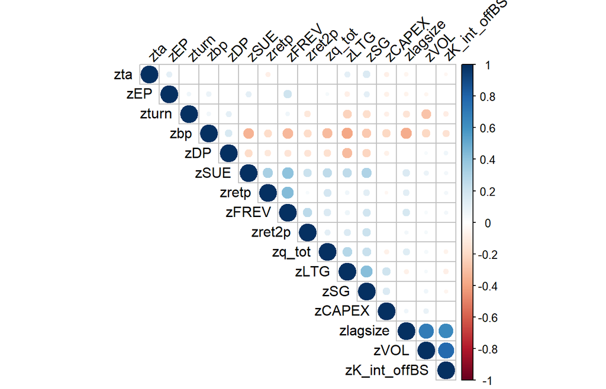

```r
res <- rcorr(as.matrix(Cor_Data))


corrplot(res$r, type="upper", order="hclust",
           tl.col = "black", tl.srt = 45,
         p.mat = res$P, sig.level = 0.01, insig = "blank")
```

### Graphs and fitted stats

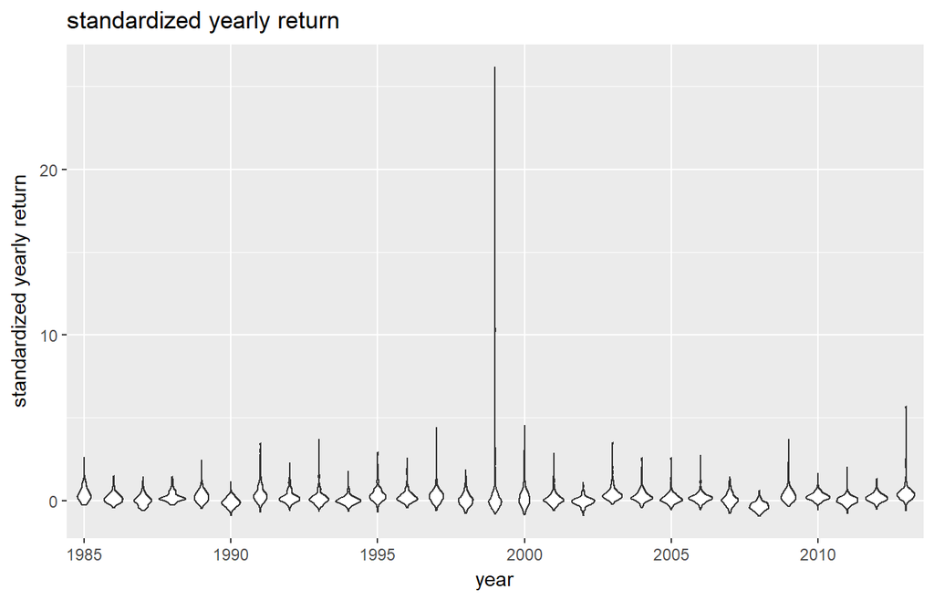

```r
Data %>% ggplot(mapping=aes(x=factor(year), y=yearlyRet)) +
  geom_violin() +
  scale_x_discrete(breaks=seq(1980, 2015, 5))+
   labs(title="standardized yearly return ",
         x = "year",
         y = "standardized yearly return")
```

```r
Data_In1 <- Data_In %>% filter(year != 1999)

gap_fit <- lm(formula = yearlyRet ~ year + zretp + zret2p + zturn + zlagsize + zFREV + zLTG + zSUE + zSG + zta + zCAPEX + zbp + zEP + zDP + zVOL + zq_tot + zK_int_offBS, data=Data_In1)

gap_fit_stats <- gap_fit %>%
  tidy()

knitr::kable(gap_fit_stats, format = "markdown")
```

| term | estimate | std.error | statistic | p.value |
| --- | --- | --- | --- | --- |
| (Intercept) | -8.4193153 | 2.9302435 | -2.8732477 | 0.0040814 |
| year | 0.0043250 | 0.0014711 | 2.9400459 | 0.0032980 |
| zretp | 0.0282914 | 0.0066914 | 4.2280050 | 0.0000240 |
| zret2p | 0.0150185 | 0.0062253 | 2.4125054 | 0.0158822 |
| zturn | 0.0002136 | 0.0064600 | 0.0330723 | 0.9736184 |
| zlagsize | -0.0479979 | 0.0093157 | -5.1523547 | 0.0000003 |
| zFREV | 0.0092893 | 0.0073189 | 1.2692160 | 0.2044282 |
| zLTG | -0.0264486 | 0.0075392 | -3.5081253 | 0.0004556 |
| zSUE | -0.0124399 | 0.0068979 | -1.8034411 | 0.0713844 |
| zSG | 0.0005290 | 0.0068700 | 0.0769964 | 0.9386297 |
| zta | -0.0299439 | 0.0059741 | -5.0122540 | 0.0000006 |
| zCAPEX | -0.0092563 | 0.0061737 | -1.4993136 | 0.1338609 |
| zbp | 0.0402549 | 0.0075579 | 5.3261728 | 0.0000001 |
| zEP | -0.0163874 | 0.0061765 | -2.6531845 | 0.0080010 |
| zDP | -0.0828134 | 0.0062132 | -13.3285435 | 0.0000000 |
| zVOL | -0.0026452 | 0.0108538 | -0.2437145 | 0.8074628 |
| zq_tot | 0.1023892 | 0.0065961 | 15.5226415 | 0.0000000 |
| zK_int_offBS | 0.0617827 | 0.0098131 | 6.2959456 | 0.0000000 |

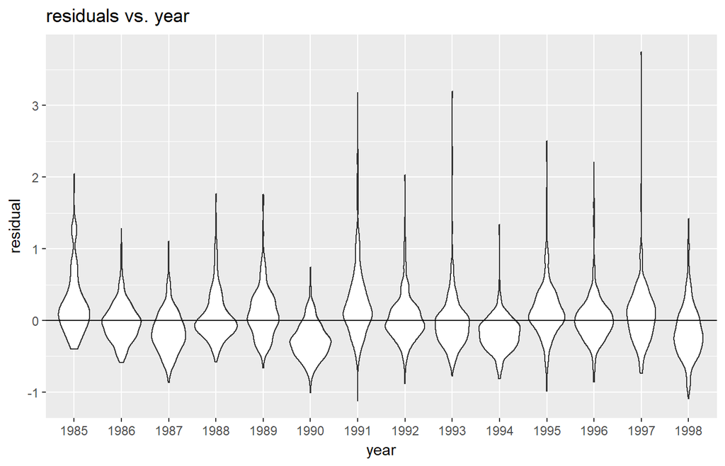

```r
augmented_gap_fit <- gap_fit %>%
  augment()

augmented_gap_fit %>%
  ggplot(mapping=aes(x=factor(year), y=.resid)) +
  geom_violin() +
  labs(title="residuals vs. year ",
         x = "year",
         y = "residual") +
  geom_hline(yintercept = 0)
```

## Conclusion

Here I have showed you a quick tutorial for how to conduct a backtesting using R. We use ML concepts where we divid the data into training and testing period. We keep running the data against the training and then check the t-stat and only pick the significant factors for the training. After that we want to run the corelation and evaluate the data and see if we can make any imporvement. If we can make an improvement we then want to go back to the model and adjust the model. Here I showed you one step in the process you then can use the code I provided to go back and make any adjustment using the result we get from the violin plot or come up with new factors to improve this model.

Here is a good read if you want to make a model like this : https://www.quantstart.com/articles/Should-You-Build-Your-Own-Backtester

In this model, we have a few biases that I made which can affect the result such as only picking the significant factors and not run the correlation matrix first. As well as removing data period that didn’t produce a good result. Ideally, we want to randomize the data periods and randomly split the data period so year to year is less correlated and we can on some of the factors and train the model. But that’s it from me. Good luck making your model and beat the market!